# Event Sourcing

Event Sourcing basics - Nimma.codes 25-10-2022

Bèr `berkes` Kessels

# Event Sourcing

## Over deze presentatie

- Is online: berk.es/es (github.com/berkes/es)
- Bevat alle links
- Is in het Nederlands

## Over mij

- Bèr `berkes` Kessels
- @berkes - LinkedIn, Twitter, Fediverse
- CTO at [REDACTED]
- Blog berk.es

## Doel

- Wegwijs worden in de chaos van TLAs.
- Een volgend project met ES opzetten?

# Event Sourcing is simpel.

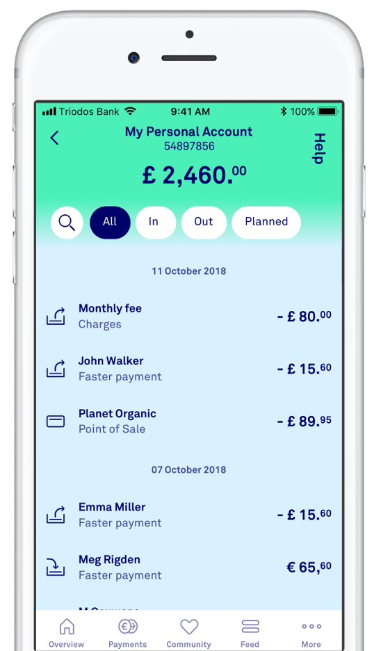

Bank app

Aggregate, Left Fold, Reduce, Projection, etc.

We slaan alle transacties op - events. Balans krijgen we door ze te doorlopen.

- Wat was onze balans op vrijdag de 13e om 13:37?
- Hoeveel dagen hebben we rood gestaan?
- Teken een diagram van ons loon over de jaren heen.

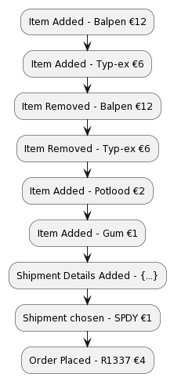

Cart Flow

- Wat zouden we een klant die een balpen koopt nog meer aanraden?
- Bij welke prijzen gaan klanten producten uit de winkelwagen halen?
- Wanneer kan voorraad gereserveerd worden?

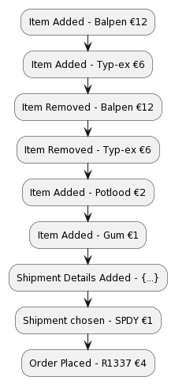

Cart ES

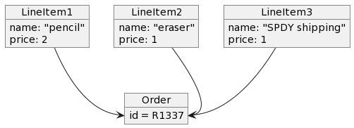

Cart State

- Audit Log
- Toekomstige analyse
- Data representeert de werkelijkheid

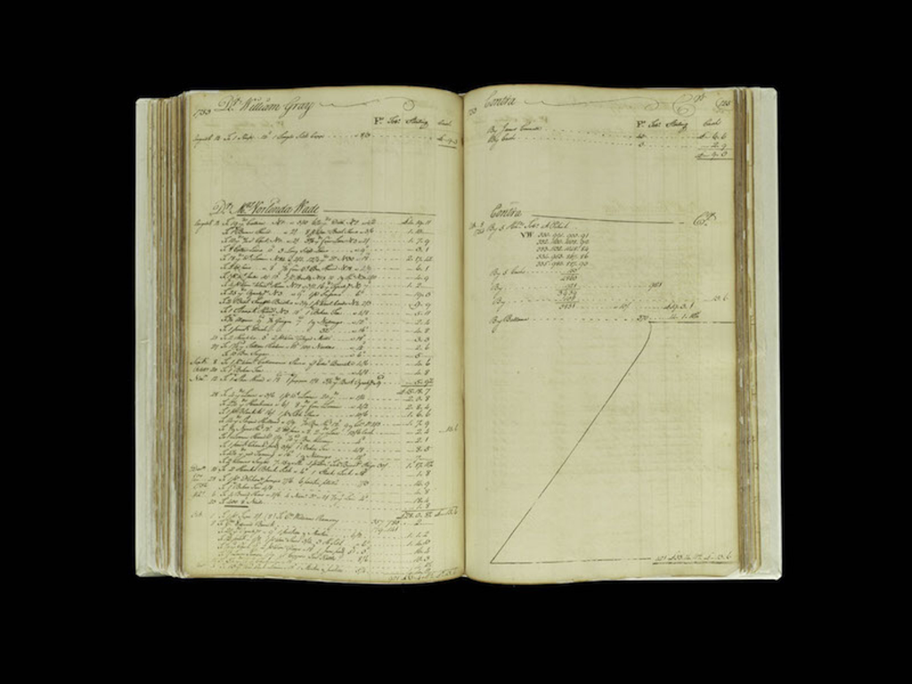

Journal Bookkeeping

- Git
- Bank - Boekhouden
- Blockchain
- AWS

> Het algemene doel van een logboek is dat later teruggelezen kan worden wat er precies gebeurd is op een bepaald moment. Op het moment van opschrijven is dus nog niet bekend wat men later terug wil lezen. Het is dus van groot belang dat alle details in het logboek terechtkomen, zodat men later niets mist.

> Ook is het van belang dat de vastleggingen in een logboek authentiek zijn. De gegevens mogen niet verwijderd of ongecontroleerd gemuteerd worden.

[Wikipedia Logboek](https://nl.wikipedia.org/wiki/Logboek)

[figure not shown]

Events: Immutable. Event Log: Append Only

- Hoe herstel je een foute “X aangemaakt” of “Y verwijderd”?
- Met een tegengestelde “X weggehaald” of “Y toegevoegd”.
- En nooit door X-aangemaakt of Y-verwijderd te verwijderen.

[figure not shown]

DDD Book cover

```ruby
##
# A position is the amount of a security, asset, or property
# that is owned (or sold short) by some individual or other entity.
class Position
  attr_reader :total_buying_price, :amount

  def initialize(ticker:, currency:)
    @events = []
    @ticker = ticker
    @currency = currency
    @total_buying_price = 0
    @amount = 0
  end

  def buy(amount:, price:)
    handle_event(
      PositionIncreased.new(
        amount: amount,
        price: price
      )
    )
  end

  def sell(amount:, price:)
    fail "Cannot sell more than #{@amount}" if amount > @amount
    handle_event(PositionReduced.new(amount: amount, price: price))
  end

  private

  ##
  # Handles an incoming event.
  # For now, we keep it simple: no DSLs or fancy metaprogramming, just a switch.
  def handle_event(event)
    @events << event
    case event
    when PositionIncreased then handle_position_increased(event)
    when PositionReduced   then handle_position_reduced(event)
    end
  end

  ##
  # Our handle_event calls this method for each PositionAdded event
  def handle_position_increased(event)
    @amount += event.amount
    @total_buying_price += event.amount * event.price
  end

  ##
  # Our handle_event calls this method for each PositionAdded event
  def handle_position_reduced(event)
    @amount -= event.amount
  end
end

class PositionIncreased < OpenStruct
end
class PositionReduced < OpenStruct
end
```

```ruby
aapl = Position.new(ticker: 'AAPL', currency: 'USD')
aapl.buy(amount: 2, price: 131.13)
aapl.sell(amount: 1, price: 142.00)
aapl.buy(amount: 3, price: 172.42)
puts aapl.total_buying_price
# 779.52
puts aapl.amount
# 4
```

- Heel makkelijk te testen.
- Zeer eenvoudig uit te breiden.
- Business logic: cohesive.

```ruby
class Aggregate
  def load(id, event_repo)
    instance = new(id, event_repo)
    events = event_repo.get_all_for(id)
    events.each do |event|
      instance.handle_event(event)
    end
    instance
  end

  def initialize(id, event_repo)
    @id = id
    @event_repo = event_repo
  end

  def handle_event(event)
    event_repo.add(@id, event)
  end
end

class Position < Aggregate
  def initialize(id, event_repo)
    super(id, event_repo)
    @opened = false
  end

  def open(ticker: ticker, currency: currency)
    handle_event(PositionOpened.new(ticker: ticker, currency: currency))
  end

  def buy()
    fail "must first open the position before buying stocks" unless @opened
    #...
  end

  def handle_event(event)
    super(event)
    # ...
  end

  def handle_open(event)
    @ticker = event.ticker
    @currency = event.currency
    @opened = true
  end
end

aapl = Position.load('AAPL-USD', pg_event_store)
aapl.open(ticker: 'AAPL', currency: 'USD')
aapl.buy(amount: 2, price: 131.13)
aapl.sell(amount: 1, price: 142.00)

aapl = Position.load('AAPL-USD', pg_event_store)
aapl.buy(amount: 3, price: 172.42)
puts aapl.total_buying_price
# 779.52
puts aapl.amount
# 4
```

# The world of ES

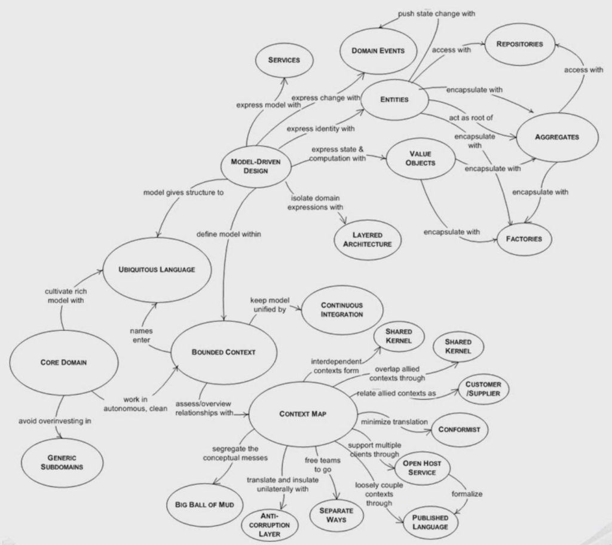

## Event-X

Eventbased, event-driven, event-bus, event-loop, event-passing, event-streaming

## Aggregate

- Root Aggregate.
- Onze “Position” was een Root Aggregate.
- Position werd “gehydrate” vanuit de event source.

## CQRS

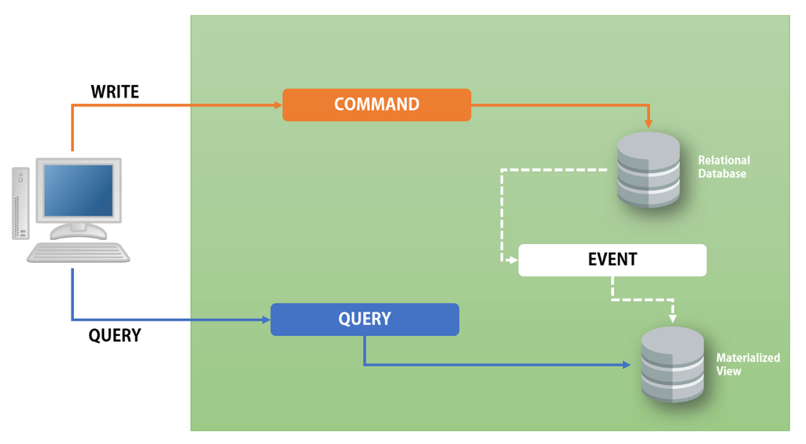

## Projection

- AKA Materialized View
- Gebouwd door een Projector
- Query Handler kan hierin lezen
- Bijv een `PositionOpened` wordt door de `OpenPositionsProjector` afgehandeld, welke eeen simpel lijstje van alle `position.id`s bijhoudt.

## Reactors

- Event Handlers (Projector is er een)
- Reactors trigger behaviour
- Nieuwe events uitzenden
- Veranderen de buitenwereld (notificaties, calls, etc)

## Commands, Command Handlers

- De publieke API.
- Commands zijn intenties: tegenwoordige tijd: OpenPosition.
- Command Handlers bevatten validatie.

## Overview

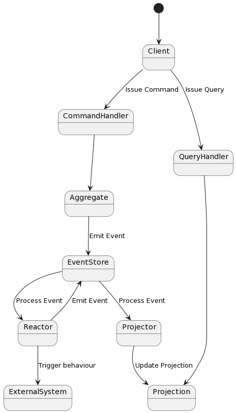

# Pro’s and cons

- Eventual-consistency is lastig.
- Weinig frameworks - weinig documentatie.
- Vereist domeinkennis.
- Complexe dataflow.
- Makkelijk te testen, valideren, debuggen en beredeneren.
- Schaalbaar in alle richtingen.
- Past domeinkennis.
- Logische dataflow

# Resources

- Domain-Driven Design: Tackling Complexity in the Heart of Software - Eric Evans
- Implementing Domain-Driven Design - Vaugh Vernon
- [Martin Fowler on Event Sourcing](https://martinfowler.com/eaaDev/EventSourcing.html)
- [DDD, CQRS and Event Sourcing - Talk by Greg Young](https://www.youtube.com/watch?v=LDW0QWie21s)